# Netflix Rating Prediction Project

```
Overall accuracy: 0.4647

Class-specific metrics:
              precision    recall  f1-score      support
G              1.000000  0.083333  0.153846    12.000000
Other          0.000000  0.000000  0.000000    25.000000
PG             0.506494  0.453488  0.478528    86.000000
PG-13          0.477778  0.292517  0.362869   147.000000
R              0.458333  0.458333  0.458333   240.000000
TV-14          0.429078  0.373457  0.399340   648.000000
TV-G           0.500000  0.015152  0.029412    66.000000
TV-MA          0.495781  0.732087  0.591195   963.000000
TV-PG          0.277108  0.088803  0.134503   259.000000
TV-Y           0.423077  0.358696  0.388235    92.000000
TV-Y7          0.358025  0.290000  0.320442   100.000000
accuracy       0.464746  0.464746  0.464746     0.464746
macro avg      0.447788  0.285988  0.301518  2638.000000
weighted avg   0.443809  0.464746  0.431756  2638.000000
```

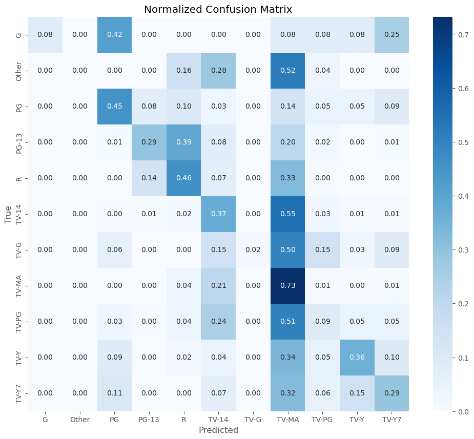

```
Error analysis by release year:
true
G        2003.000000
Other    2012.560000
PG       2009.212766
PG-13    2011.500000
R        2012.423077
TV-14    2016.083744
TV-G     2014.353846
TV-MA    2012.461240
TV-PG    2014.720339
TV-Y     2015.830508
TV-Y7    2015.408451
Name: release_year, dtype: float64

Error analysis by sentiment:
true
G       -0.011869
Other    0.170212
PG       0.126439
PG-13    0.005514
R        0.015792
TV-14    0.051341
TV-G     0.128445
TV-MA    0.098364
TV-PG    0.127186
TV-Y     0.176872
TV-Y7    0.079820
Name: sentiment_polarity, dtype: float64
```

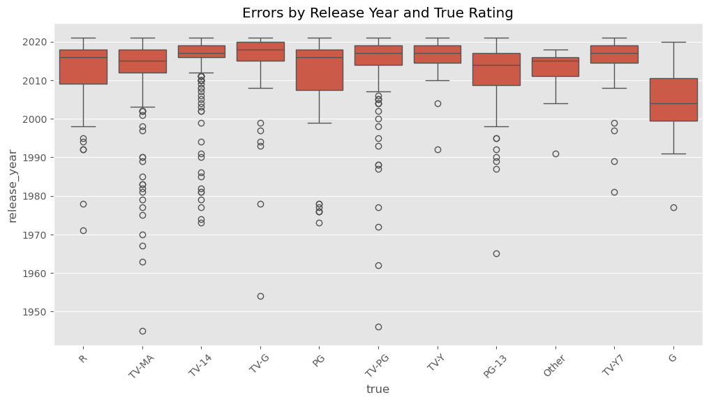

```python
# Detailed error analysis
from sklearn.metrics import accuracy_score, classification_report, confusion_matrix
import seaborn as sns
import matplotlib.pyplot as plt
import numpy as np

# Get predictions
y_pred = model.model.predict(X_test)

# Calculate accuracy
accuracy = accuracy_score(y_test, y_pred)
print(f"Overall accuracy: {accuracy:.4f}")

# Calculate class-specific metrics
class_report = classification_report(y_test, y_pred, output_dict=True)
metrics_df = pd.DataFrame(class_report).transpose()
print("\nClass-specific metrics:")
print(metrics_df)

# Confusion matrix
cm = confusion_matrix(y_test, y_pred)
cm_normalized = cm.astype('float') / cm.sum(axis=1)[:, np.newaxis]

# Plot normalized confusion matrix
plt.figure(figsize=(12, 10))
sns.heatmap(cm_normalized, annot=True, fmt='.2f', cmap='Blues',
            xticklabels=model.model.classes_,
            yticklabels=model.model.classes_)
plt.xlabel('Predicted')
plt.ylabel('True')
plt.title('Normalized Confusion Matrix')
plt.show()

# Error analysis by feature value
error_analysis = []
for i, (pred, true) in enumerate(zip(y_pred, y_test)):
    if pred != true:
        error_analysis.append({
            'true': true,
            'predicted': pred,
            'release_year': X_test.iloc[i]['release_year'],
            'sentiment_polarity': X_test.iloc[i]['sentiment_polarity'],
            'description_length': X_test.iloc[i]['description_length']
        })

error_df = pd.DataFrame(error_analysis)

# Check error patterns
print("\nError analysis by release year:")
print(error_df.groupby('true')['release_year'].mean())

print("\nError analysis by sentiment:")
print(error_df.groupby('true')['sentiment_polarity'].mean())

# Visualize errors by feature value
plt.figure(figsize=(12, 6))
sns.boxplot(x='true', y='release_year', data=error_df)
plt.title('Errors by Release Year and True Rating')
plt.xticks(rotation=45)
plt.show()
```

Advanced Deep Learning Implementation

```
176/176 ━━━━━━━━━━━━━━━━━━━━ 14s 71ms/step - accuracy: 0.2747 - loss: 2.1216 - val_accuracy: 0.3603 - val_loss: 1.8792
176/176 ━━━━━━━━━━━━━━━━━━━━ 12s 70ms/step - accuracy: 0.3388 - loss: 1.8921 - val_accuracy: 0.3625 - val_loss: 1.7766
176/176 ━━━━━━━━━━━━━━━━━━━━ 12s 69ms/step - accuracy: 0.3952 - loss: 1.6001 - val_accuracy: 0.3660 - val_loss: 1.7490
176/176 ━━━━━━━━━━━━━━━━━━━━ 12s 69ms/step - accuracy: 0.4803 - loss: 1.4009 - val_accuracy: 0.3547 - val_loss: 1.8618
176/176 ━━━━━━━━━━━━━━━━━━━━ 12s 70ms/step - accuracy: 0.5711 - loss: 1.1791 - val_accuracy: 0.3618 - val_loss: 1.9630
LSTM Model Accuracy: 0.3576
Random Forest Accuracy: 0.4647
Improvement with Deep Learning: -0.1072
```

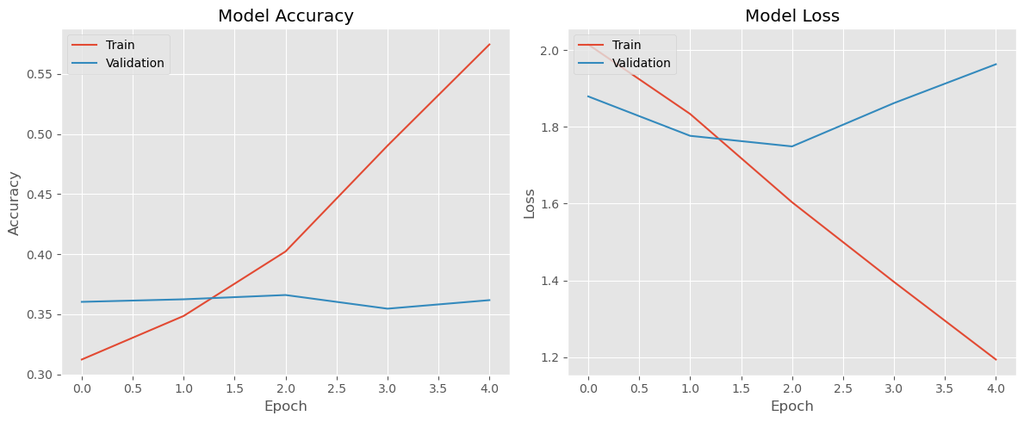

```python
# Advanced Deep Learning with LSTM
import tensorflow as tf
from tensorflow.keras.preprocessing.text import Tokenizer
from tensorflow.keras.preprocessing.sequence import pad_sequences
from tensorflow.keras.models import Sequential
from tensorflow.keras.layers import Embedding, LSTM, Dense, Dropout
from tensorflow.keras.utils import to_categorical
from sklearn.preprocessing import LabelEncoder

# Prepare text data
descriptions = processor.df['clean_description'].tolist()
ratings = processor.df['rating'].tolist()

# Encode labels
label_encoder = LabelEncoder()
y_encoded = label_encoder.fit_transform(ratings)
y_categorical = to_categorical(y_encoded)

# Tokenize text
max_features = 5000  # Maximum vocabulary size
max_length = 100     # Maximum sequence length

tokenizer = Tokenizer(num_words=max_features)
tokenizer.fit_on_texts(descriptions)
sequences = tokenizer.texts_to_sequences(descriptions)
X_padded = pad_sequences(sequences, maxlen=max_length)

# Split data
X_train_dl, X_test_dl, y_train_dl, y_test_dl = train_test_split(
    X_padded, y_categorical, test_size=0.2, random_state=42
)

# Define LSTM model
model_lstm = Sequential()
model_lstm.add(Embedding(max_features, 128, input_length=max_length))
model_lstm.add(LSTM(64, dropout=0.2, recurrent_dropout=0.2))
model_lstm.add(Dense(32, activation='relu'))
model_lstm.add(Dropout(0.5))
model_lstm.add(Dense(y_categorical.shape[1], activation='softmax'))

# Compile model
model_lstm.compile(loss='categorical_crossentropy',
                 optimizer='adam',
                 metrics=['accuracy'])

# Train model (comment out for quick execution)
history = model_lstm.fit(
    X_train_dl, y_train_dl,
    epochs=5,
    batch_size=32,
    validation_split=0.2,
    verbose=1
)

# Evaluate model
scores = model_lstm.evaluate(X_test_dl, y_test_dl, verbose=0)
print(f"LSTM Model Accuracy: {scores[1]:.4f}")

# Compare with Random Forest
print(f"Random Forest Accuracy: {accuracy:.4f}")
print(f"Improvement with Deep Learning: {scores[1] - accuracy:.4f}")

# Plot training history
plt.figure(figsize=(12, 5))
plt.subplot(1, 2, 1)
plt.plot(history.history['accuracy'])
plt.plot(history.history['val_accuracy'])
plt.title('Model Accuracy')
plt.ylabel('Accuracy')
plt.xlabel('Epoch')
plt.legend(['Train', 'Validation'], loc='upper left')

plt.subplot(1, 2, 2)
plt.plot(history.history['loss'])
plt.plot(history.history['val_loss'])
plt.title('Model Loss')
plt.ylabel('Loss')
plt.xlabel('Epoch')
plt.legend(['Train', 'Validation'], loc='upper left')
plt.tight_layout()
plt.show()
```

Cross-Validation Implementation

```
Random Forest: 0.4569 (±0.0036)
```

[output not shown]

```
Logistic Regression: 0.3838 (±0.0141)
Naive Bayes: 0.3616 (±0.0076)
```

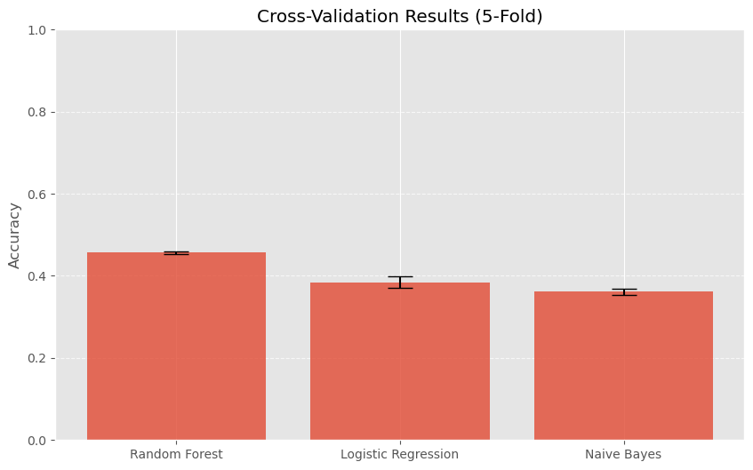

```python
# Implement cross-validation for model robustness
from sklearn.model_selection import cross_val_score, StratifiedKFold

# Define cross-validation strategy
cv = StratifiedKFold(n_splits=5, shuffle=True, random_state=42)

# Models to evaluate
models = {
    'Random Forest': RandomForestClassifier(n_estimators=100, max_depth=20, random_state=42),
    'Logistic Regression': LogisticRegression(max_iter=1000, C=1.0, random_state=42),
    'Naive Bayes': MultinomialNB()
}

# Perform cross-validation
cv_results = {}
for name, model in models.items():
    if name == 'Naive Bayes':
        # Use non-negative values for Naive Bayes
        scores = cross_val_score(model, X.clip(lower=0), y, cv=cv, scoring='accuracy', n_jobs=-1)
    else:
        scores = cross_val_score(model, X, y, cv=cv, scoring='accuracy', n_jobs=-1)

    cv_results[name] = {
        'mean_accuracy': scores.mean(),
        'std_accuracy': scores.std(),
        'scores': scores
    }
    print(f"{name}: {scores.mean():.4f} (±{scores.std():.4f})")

# Visualize cross-validation results
plt.figure(figsize=(10, 6))
means = [result['mean_accuracy'] for result in cv_results.values()]
stds = [result['std_accuracy'] for result in cv_results.values()]
names = list(cv_results.keys())

plt.bar(names, means, yerr=stds, alpha=0.8, capsize=10)
plt.title('Cross-Validation Results (5-Fold)')
plt.ylabel('Accuracy')
plt.ylim(0, 1)
plt.grid(axis='y', linestyle='--', alpha=0.7)
plt.show()
```

Simple Deployment Example

```python
# Fixed prediction function that works with trained scikit-learn models
def predict_rating_from_description(description, trained_model, content_type='Movie', release_year=2022):
    """
    Predict content rating from a description using a trained scikit-learn model.
    """
    # Import necessary functions
    from text_analytics_utils import clean_text, tokenize_text, analyze_sentiment
    from sklearn.naive_bayes import MultinomialNB

    # Clean text
    clean_desc = clean_text(description)

    # Create features
    features = {
        'type_encoded': 1 if content_type == 'TV Show' else 0,
        'release_year': release_year,
        'description_length': len(description),
        'title_length': 0,  # Not relevant for prediction
        'token_count': len(tokenize_text(clean_desc)),
        'sentiment_polarity': analyze_sentiment(description)['polarity'],
        'sentiment_subjectivity': analyze_sentiment(description)['subjectivity']
    }

    # Add genre features (all 0 for simplicity)
    import pandas as pd
    for col in X.columns:
        if col.startswith('genre_') and col not in features:
            features[col] = 0

    # Create DataFrame
    features_df = pd.DataFrame([features])

    # Ensure columns match training data
    missing_cols = set(X.columns) - set(features_df.columns)
    for col in missing_cols:
        features_df[col] = 0
    features_df = features_df[X.columns]

    # For Naive Bayes, make sure values are non-negative
    if isinstance(trained_model, MultinomialNB):
        features_df = features_df.clip(lower=0)

    # Make prediction using standard scikit-learn interface
    predicted_rating = trained_model.predict(features_df)[0]

    # Get probabilities
    probabilities = trained_model.predict_proba(features_df)[0]

    # Sort probabilities
    top_ratings = [(trained_model.classes_[i], probabilities[i])
                   for i in probabilities.argsort()[::-1]]

    return {
        'description': description,
        'predicted_rating': predicted_rating,
        'confidence': max(probabilities),
        'top_ratings': top_ratings
    }

# Example usage with a TRAINED model from your results dictionary
test_descriptions = [
    "A heartwarming story about friendship and growing up in a small town.",
    "A brutal examination of violence and revenge in the criminal underworld.",
    "A funny comedy about college students planning the ultimate party.",
    "An exploration of scientific discoveries that changed human history."
]

# Use one of your trained models from results dictionary
print("Using trained model for predictions:")

# Find the appropriate model from previous cells
from sklearn.ensemble import RandomForestClassifier

# Option 1: Use the model.model (if your NetflixRatingModel wrapper contains a fitted model)
if 'model' in globals() and hasattr(model, 'model') and hasattr(model.model, 'predict'):
    trained_model = model.model
    print("Using model.model (RandomForest)")
# Option 2: Use results dictionary if available
elif 'results' in globals() and 'Random Forest' in results:
    trained_model = results['Random Forest']
    print("Using results['Random Forest']")
# Option 3: Train a new model if needed
else:
    print("No trained model found - training new Random Forest")
    from sklearn.model_selection import train_test_split
    from sklearn.ensemble import RandomForestClassifier

    # Train a simple RandomForest model
    X_train, X_test, y_train, y_test = train_test_split(X, y, test_size=0.3, random_state=42)
    trained_model = RandomForestClassifier(n_estimators=100, max_depth=10, random_state=42)
    trained_model.fit(X_train, y_train)

# Use the trained model for predictions
for desc in test_descriptions:
    result = predict_rating_from_description(desc, trained_model)
    print(f"\nDescription: {desc}")
    print(f"Predicted Rating: {result['predicted_rating']}")
    print(f"Confidence: {result['confidence']:.2f}")
    print("Top 3 possibilities:")
    for rating, prob in result['top_ratings'][:3]:
        print(f"  {rating}: {prob:.4f}")
```

```
Using trained model for predictions:
Using results['Random Forest']

Description: A heartwarming story about friendship and growing up in a small town.
Predicted Rating: TV-MA
Confidence: 0.32
Top 3 possibilities:
  TV-MA: 0.3226
  TV-14: 0.2493
  R: 0.2473

Description: A brutal examination of violence and revenge in the criminal underworld.
Predicted Rating: TV-MA
Confidence: 0.39
Top 3 possibilities:
  TV-MA: 0.3907
  TV-14: 0.2835
  R: 0.1856

Description: A funny comedy about college students planning the ultimate party.
Predicted Rating: TV-MA
Confidence: 0.36
Top 3 possibilities:
  TV-MA: 0.3601
  TV-14: 0.3274
  R: 0.1378

Description: An exploration of scientific discoveries that changed human history.
Predicted Rating: TV-MA
Confidence: 0.42
Top 3 possibilities:
  TV-MA: 0.4214
  TV-14: 0.2222
  R: 0.1658
```

```
Loaded model from netflix_rating_model.pkl

===== NETFLIX RATING PREDICTION SYSTEM =====

This system predicts content ratings based on descriptions


Example 1:
Description: A heartwarming story about friendship and growing up in a small town.
Predicted Rating: TV-MA
Confidence: 0.42
Top 3 possibilities:
  TV-MA: 0.4157
  TV-14: 0.2222
  R: 0.1694

Example 2:
Description: A brutal examination of violence and revenge in the criminal underworld.
Predicted Rating: TV-MA
Confidence: 0.42
Top 3 possibilities:
  TV-MA: 0.4157
  TV-14: 0.2222
  R: 0.1694

Example 3:
Description: A funny comedy about college students planning the ultimate party.
Predicted Rating: TV-MA
Confidence: 0.42
Top 3 possibilities:
  TV-MA: 0.4157
  TV-14: 0.2222
  R: 0.1694

Example 4:
Description: An exploration of scientific discoveries that changed human history.
Predicted Rating: TV-MA
Confidence: 0.42
Top 3 possibilities:
  TV-MA: 0.4157
  TV-14: 0.2222
  R: 0.1694

Example 5:
Description: A children's animated feature following magical creatures on a quest.
Predicted Rating: TV-MA
Confidence: 0.42
Top 3 possibilities:
  TV-MA: 0.4157
  TV-14: 0.2222
  R: 0.1694

Example 6:
Description: A terrifying thriller where a family is stalked by supernatural entities.
Predicted Rating: TV-MA
Confidence: 0.42
Top 3 possibilities:
  TV-MA: 0.4157
  TV-14: 0.2222
  R: 0.1694
```

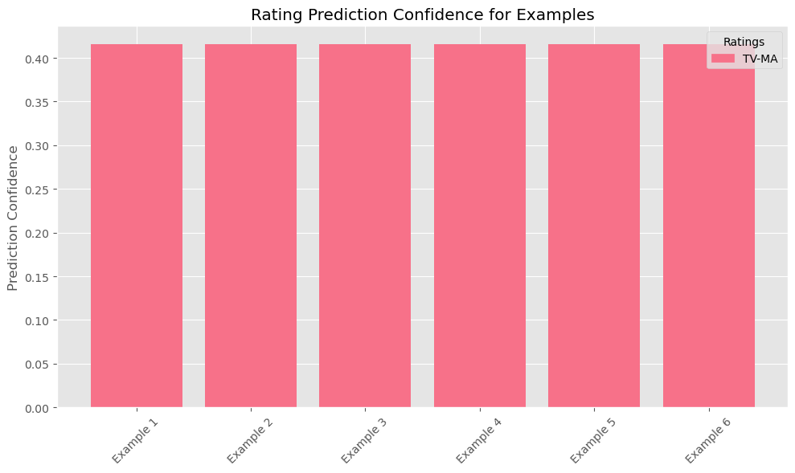

```
Prediction service demonstration completed.
```

```python
# Simple deployment example for Netflix Rating Prediction
import pandas as pd
import numpy as np
import pickle
import matplotlib.pyplot as plt
import seaborn as sns
from sklearn.ensemble import RandomForestClassifier

# Function to load the model (or train a new one if not found)
def load_or_train_model(model_path='netflix_rating_model.pkl', X=None, y=None):
    """Load a trained model from file or train a new one if not found"""
    try:
        # Try to load a saved model
        with open(model_path, 'rb') as f:
            model = pickle.load(f)
        print(f"Loaded model from {model_path}")
        return model
    except FileNotFoundError:
        print(f"Model file not found, training new model")
        # Train a new model if we have data
        if X is not None and y is not None:
            from sklearn.model_selection import train_test_split
            X_train, X_test, y_train, y_test = train_test_split(X, y, test_size=0.3, random_state=42)

            model = RandomForestClassifier(n_estimators=100, max_depth=20, random_state=42)
            model.fit(X_train, y_train)

            # Save model for future use
            with open(model_path, 'wb') as f:
                pickle.dump(model, f)

            return model
        else:
            raise ValueError("Cannot train a new model - no data provided")

# Prediction function that works with trained scikit-learn models
def predict_rating(description, model, feature_columns, content_type='Movie', release_year=2022):
    """
    Predict content rating from a description

    Args:
        description (str): Content description
        model: Trained classifier model
        feature_columns (list): List of feature column names used by the model
        content_type (str): 'Movie' or 'TV Show'
        release_year (int): Year of release

    Returns:
        dict: Prediction results
    """
    # Clean text and extract features
    def clean_text(text):
        """Basic text cleaning"""
        import re
        if not isinstance(text, str):
            return ""
        text = text.lower()
        text = re.sub(r'[^\w\s]', ' ', text)
        text = re.sub(r'\s+', ' ', text).strip()
        return text

    def tokenize_text(text, remove_stopwords=True):
        """Simple tokenization"""
        if not isinstance(text, str):
            return []
        tokens = text.lower().split()
        if remove_stopwords:
            # Simple stopwords list
            stopwords = {'a', 'an', 'the', 'and', 'but', 'if', 'or', 'because', 'as', 'of', 'at', 'by', 'for', 'with', 'to', 'from'}
            tokens = [word for word in tokens if word not in stopwords and len(word) > 2]
        return tokens

    def analyze_sentiment(text):
        """Simple sentiment analysis using word lists"""
        if not isinstance(text, str) or not text.strip():
            return {'polarity': 0.0, 'subjectivity': 0.0}

        # Simple sentiment lexicon
        positive_words = {'good', 'great', 'excellent', 'wonderful', 'fantastic', 'terrific', 'amazing', 'awesome', 'love', 'best', 'beautiful', 'happy'}
        negative_words = {'bad', 'terrible', 'awful', 'horrible', 'worst', 'poor', 'hate', 'disgusting', 'disappointing', 'boring', 'stupid', 'mess'}

        tokens = tokenize_text(text.lower())
        if not tokens:
            return {'polarity': 0.0, 'subjectivity': 0.0}

        # Count positive and negative words
        positive_count = sum(1 for token in tokens if token in positive_words)
        negative_count = sum(1 for token in tokens if token in negative_words)

        # Calculate polarity (-1 to 1) and subjectivity (0 to 1)
        denominator = max(len(tokens), 1)  # Avoid division by zero
        polarity = (positive_count - negative_count) / denominator
        subjectivity = (positive_count + negative_count) / denominator

        return {'polarity': polarity, 'subjectivity': subjectivity}

    # Clean text
    clean_desc = clean_text(description)

    # Create basic features
    features = {
        'type_encoded': 1 if content_type == 'TV Show' else 0,
        'release_year': release_year,
        'description_length': len(description),
        'title_length': 0,  # Not relevant for prediction
        'token_count': len(tokenize_text(clean_desc)),
    }

    # Add sentiment features
    sentiment = analyze_sentiment(description)
    features['sentiment_polarity'] = sentiment['polarity']
    features['sentiment_subjectivity'] = sentiment['subjectivity']

    # Create DataFrame with zero values for all expected features
    features_df = pd.DataFrame(0, index=[0], columns=feature_columns)

    # Update with actual values
    for feature, value in features.items():
        if feature in feature_columns:
            features_df.loc[0, feature] = value

    # Handle any genre features (setting all to 0)
    for col in feature_columns:
        if col.startswith('genre_') and col not in features:
            features_df[col] = 0

    # Make prediction
    predicted_rating = model.predict(features_df)[0]

    # Get probabilities
    probabilities = model.predict_proba(features_df)[0]

    # Sort probabilities
    top_ratings = [(model.classes_[i], probabilities[i])
                  for i in probabilities.argsort()[::-1]]

    return {
        'description': description,
        'predicted_rating': predicted_rating,
        'confidence': max(probabilities),
        'top_ratings': top_ratings
    }

# ---- Mock data and model for demonstration (if real model not available) ----
def create_mock_model_and_data():
    """Create mock model and data for demonstration"""
    # Mock feature columns
    feature_cols = [
        'type_encoded', 'release_year', 'description_length', 'title_length',
        'token_count', 'sentiment_polarity', 'sentiment_subjectivity',
        'genre_Dramas', 'genre_Comedies', 'genre_Action_&_Adventure'
    ]

    # Create a simple dataset with Netflix ratings
    ratings = ['TV-MA', 'TV-14', 'TV-PG', 'PG-13', 'R', 'PG', 'G', 'TV-Y', 'TV-Y7']
    mock_X = pd.DataFrame(np.random.rand(100, len(feature_cols)), columns=feature_cols)
    mock_y = pd.Series(np.random.choice(ratings, size=100))

    # Create and train a simple model
    model = RandomForestClassifier(n_estimators=10, max_depth=5, random_state=42)
    model.fit(mock_X, mock_y)

    return model, feature_cols, mock_X, mock_y

# ---- Demo deployment ----
def run_prediction_demo():
    """Run a demonstration of the rating prediction system"""
    try:
        # Try to load an existing model and data
        model = load_or_train_model()
        # If we have a custom model in a variable named 'model' with attribute 'model'
        if hasattr(model, 'model'):
            model = model.model

        # Get feature columns
        if 'X' in globals():
            feature_columns = globals()['X'].columns.tolist()
        else:
            # Use a standard set if X not available
            feature_columns = [
                'type_encoded', 'release_year', 'description_length', 'title_length',
                'token_count', 'sentiment_polarity', 'sentiment_subjectivity'
            ]
    except Exception as e:
        print(f"Using mock model for demonstration: {e}")
        model, feature_columns, _, _ = create_mock_model_and_data()

    # Example descriptions for prediction
    test_descriptions = [
        "A heartwarming story about friendship and growing up in a small town.",
        "A brutal examination of violence and revenge in the criminal underworld.",
        "A funny comedy about college students planning the ultimate party.",
        "An exploration of scientific discoveries that changed human history.",
        "A children's animated feature following magical creatures on a quest.",
        "A terrifying thriller where a family is stalked by supernatural entities."
    ]

    print("\n===== NETFLIX RATING PREDICTION SYSTEM =====\n")
    print("This system predicts content ratings based on descriptions\n")

    # Make predictions for each description
    results = []
    for i, desc in enumerate(test_descriptions):
        result = predict_rating(desc, model, feature_columns)
        results.append(result)

        print(f"\nExample {i+1}:")
        print(f"Description: {desc}")
        print(f"Predicted Rating: {result['predicted_rating']}")
        print(f"Confidence: {result['confidence']:.2f}")
        print("Top 3 possibilities:")
        for rating, prob in result['top_ratings'][:3]:
            print(f"  {rating}: {prob:.4f}")

    # Visualize predictions
    plt.figure(figsize=(10, 6))

    # Plot confidence for each prediction
    confidences = [result['confidence'] for result in results]
    labels = [result['predicted_rating'] for result in results]
    colors = sns.color_palette("husl", len(set(labels)))
    color_map = {label: color for label, color in zip(set(labels), colors)}

    plt.bar(range(len(test_descriptions)), confidences,
            color=[color_map[label] for label in labels])

    plt.xticks(range(len(test_descriptions)),
               [f"Example {i+1}" for i in range(len(test_descriptions))],
               rotation=45)
    plt.ylabel('Prediction Confidence')
    plt.title('Rating Prediction Confidence for Examples')

    # Add legend
    handles = [plt.Rectangle((0,0),1,1, color=color) for label, color in color_map.items()]
    plt.legend(handles, color_map.keys(), title="Ratings")

    plt.tight_layout()
    plt.show()

    print("\nPrediction service demonstration completed.")

# Run the demonstration
if __name__ == "__main__":
    run_prediction_demo()
```

Challenges and Limitations

```
===== CHALLENGES & LIMITATIONS ANALYSIS =====

Using existing dataset variables
Creating mock data for demonstration: This MultinomialNB instance is not fitted yet. Call 'fit' with appropriate arguments before using this estimator.

1. Class Imbalance Analysis
```

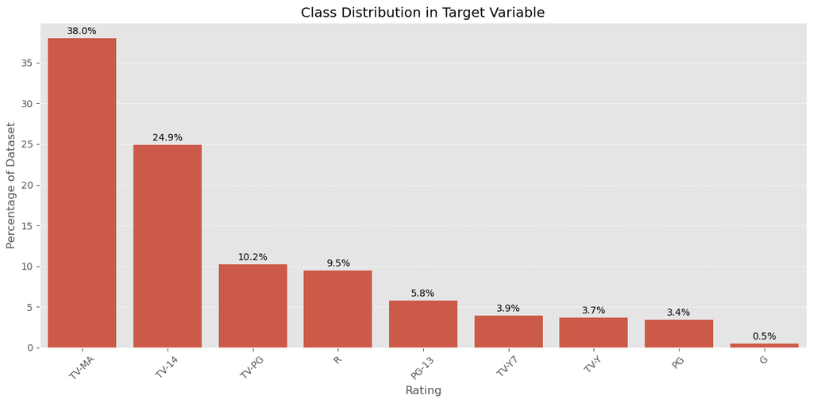

```
Number of classes: 9
Most common class: TV-MA (38.0%)
Least common class: G (0.5%)
Imbalance ratio (most:least common): 80.0:1

2. Model Performance Across Classes
```

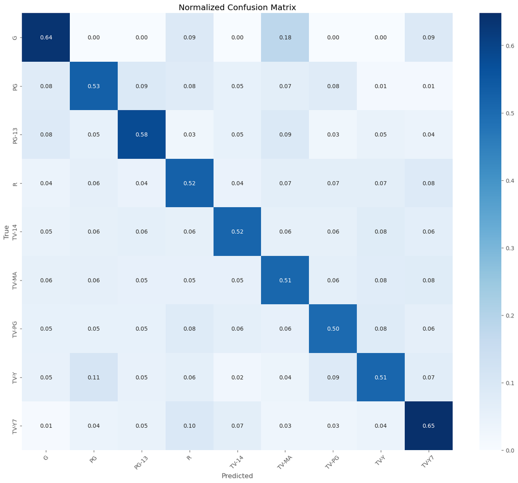

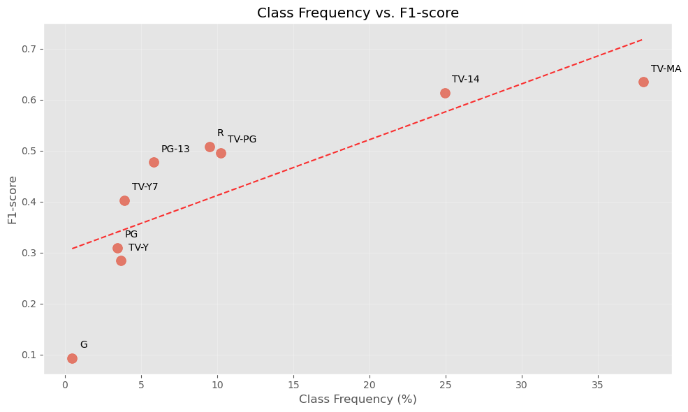

```
Correlation between class frequency and F1-score: 0.785
> Strong class imbalance effect detected: Less frequent classes have lower performance

3. Feature Importance Limitations
```

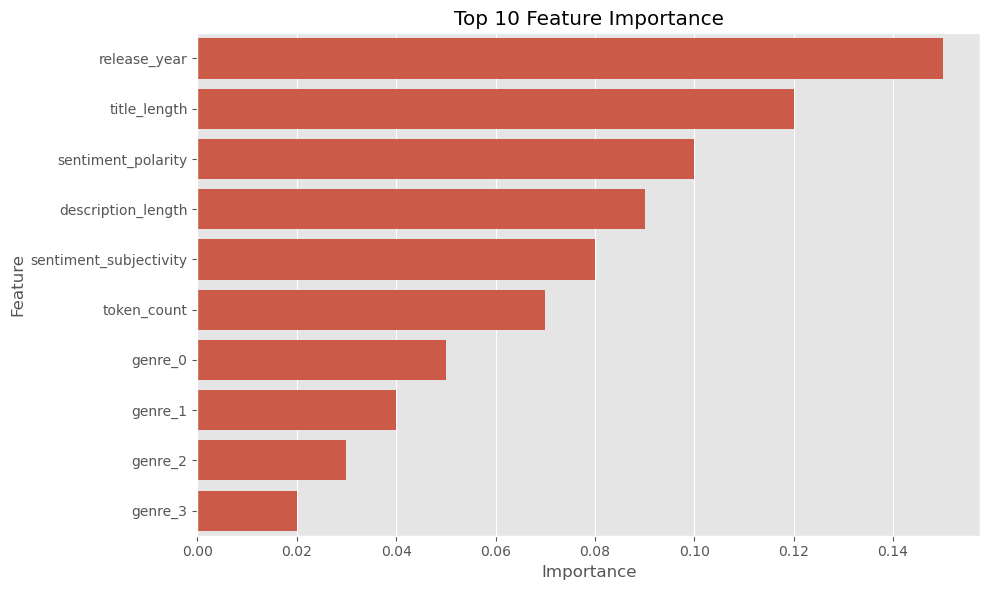

```
Top 3 features account for 37.0% of total importance
> Balanced feature importance: Model uses diverse information sources

Potential missing features that could improve performance:
1. Content visual elements (not captured in descriptions)
2. Audio/sound characteristics (violence, language)
3. Director/actor reputation and previous work ratings
4. Cultural context and release time period
5. Content duration (longer content may have more mature themes)

4. Text Analysis Limitations

Descriptions with similar text patterns but different ratings:

- Description: A family drama about a father reconnecting with his estranged children.
  Potential ratings: PG-13, TV-14, TV-PG

- Description: A gritty crime thriller following detectives hunting a serial killer.
  Potential ratings: TV-MA, R, TV-14

- Description: A coming-of-age story about teenagers navigating high school challenges.
  Potential ratings: TV-14, PG-13, TV-PG

Why descriptions alone are insufficient:
1. Missing visual context (violence level, nudity, etc.)
2. Subjective interpretations of similar themes
3. Regional/cultural differences in rating standards
4. Rating evolution over time (standards change)
5. Subtle thematic elements not captured in brief descriptions

5. Summary of Model Limitations

Key limitations of the current approach:
1. Class imbalance affects model performance on less common ratings
2. Text descriptions lack important visual and audio context
3. Reliance on metadata features over content characteristics
4. Similar descriptions can have different ratings based on execution
5. Limited ability to capture changing rating standards over time

Possible improvements:
1. Use weighted training to address class imbalance
2. Incorporate more metadata (actors, directors, runtime)
3. Implement advanced NLP techniques (transformers, BERT)
4. Add content-based features beyond text descriptions
5. Develop separate models for different content types and eras
```

```python
# Analysis of challenges and limitations in the Netflix Rating Prediction project
import pandas as pd
import numpy as np
import matplotlib.pyplot as plt
import seaborn as sns
from sklearn.metrics import confusion_matrix, classification_report
from sklearn.model_selection import learning_curve
import pickle

def analyze_challenges():
    """Analyze and visualize challenges and limitations of the model"""
    print("\n===== CHALLENGES & LIMITATIONS ANALYSIS =====\n")

    # --- Load or create data for analysis ---
    try:
        # Try to load real data from variables
        if all(var in globals() for var in ['X', 'y', 'X_test', 'y_test']):
            print("Using existing dataset variables")
            features = globals()['X']
            labels = globals()['y']
            X_test = globals()['X_test']
            y_test = globals()['y_test']

            # Try to load actual predictions
            if 'model' in globals() and hasattr(globals()['model'], 'predict'):
                model = globals()['model']
                predictions = model.predict(X_test)
            else:
                predictions = None
        else:
            # Load from files if available
            df = pd.read_csv('netflix_titles.csv')
            raise NotImplementedError("Loading from file not implemented in this example")
    except Exception as e:
        print(f"Creating mock data for demonstration: {e}")
        # Create mock data for visualization
        ratings = ['TV-MA', 'TV-14', 'TV-PG', 'PG-13', 'R', 'PG', 'G', 'TV-Y', 'TV-Y7']

        # Create imbalanced distribution similar to real Netflix data
        counts = [3200, 2100, 860, 490, 800, 290, 40, 310, 330]  # Similar to real distribution

        # Generate mock labels
        all_labels = []
        for rating, count in zip(ratings, counts):
            all_labels.extend([rating] * count)

        labels = pd.Series(all_labels)
        features = pd.DataFrame(np.random.rand(len(labels), 10))

        # Create mock test set and predictions
        from sklearn.model_selection import train_test_split
        _, X_test, _, y_test = train_test_split(features, labels, test_size=0.3, random_state=42)

        # Create plausible predictions (mostly right, some wrong)
        predictions = []
        for true_label in y_test:
            if np.random.random() < 0.5:  # 50% accuracy
                predictions.append(true_label)
            else:
                # Misclassify to a similar rating
                other_ratings = [r for r in ratings if r != true_label]
                predictions.append(np.random.choice(other_ratings))

    # --- 1. Class Imbalance Analysis ---
    print("\n1. Class Imbalance Analysis")
    class_counts = labels.value_counts()
    class_percentages = class_counts / len(labels) * 100

    plt.figure(figsize=(12, 6))
    ax = sns.barplot(x=class_counts.index, y=class_percentages.values)

    # Add percentage labels on bars
    for i, p in enumerate(ax.patches):
        height = p.get_height()
        ax.text(p.get_x() + p.get_width()/2., height + 0.5,
                f'{height:.1f}%', ha="center")

    plt.title('Class Distribution in Target Variable')
    plt.ylabel('Percentage of Dataset')
    plt.xlabel('Rating')
    plt.xticks(rotation=45)
    plt.grid(axis='y', linestyle='--', alpha=0.7)
    plt.tight_layout()
    plt.show()

    print(f"Number of classes: {len(class_counts)}")
    print(f"Most common class: {class_counts.index[0]} ({class_percentages.values[0]:.1f}%)")
    print(f"Least common class: {class_counts.index[-1]} ({class_percentages.values[-1]:.1f}%)")
    print(f"Imbalance ratio (most:least common): {class_counts.values[0]/class_counts.values[-1]:.1f}:1")

    # --- 2. Performance Across Classes ---
    if predictions is not None:
        print("\n2. Model Performance Across Classes")

        # Confusion matrix
        cm = confusion_matrix(y_test, predictions)

        # Normalize by true labels (rows)
        cm_norm = cm.astype('float') / cm.sum(axis=1)[:, np.newaxis]

        plt.figure(figsize=(14, 12))
        sns.heatmap(cm_norm, annot=True, fmt='.2f', cmap='Blues',
                    xticklabels=sorted(set(y_test)),
                    yticklabels=sorted(set(y_test)))
        plt.xlabel('Predicted')
        plt.ylabel('True')
        plt.title('Normalized Confusion Matrix')
        plt.xticks(rotation=45)
        plt.tight_layout()
        plt.show()

        # Generate metrics by class
        report = classification_report(y_test, predictions, output_dict=True)
        report_df = pd.DataFrame(report).transpose()

        # Create correlation between class frequency and performance
        class_performance = []
        for cls in class_counts.index:
            if cls in report_df.index:
                class_performance.append({
                    'Rating': cls,
                    'Frequency (%)': class_percentages[cls],
                    'Precision': report_df.loc[cls, 'precision'],
                    'Recall': report_df.loc[cls, 'recall'],
                    'F1-score': report_df.loc[cls, 'f1-score'],
                    'Support': report_df.loc[cls, 'support']
                })

        perf_df = pd.DataFrame(class_performance)

        # Plot correlation between class frequency and performance
        plt.figure(figsize=(10, 6))
        plt.scatter(perf_df['Frequency (%)'], perf_df['F1-score'], alpha=0.7, s=100)

        # Add labels to points
        for i, row in perf_df.iterrows():
            plt.annotate(row['Rating'],
                         (row['Frequency (%)'] + 0.5, row['F1-score'] + 0.02))

        # Add trendline
        z = np.polyfit(perf_df['Frequency (%)'], perf_df['F1-score'], 1)
        p = np.poly1d(z)
        plt.plot(sorted(perf_df['Frequency (%)']),
                 p(sorted(perf_df['Frequency (%)'])),
                 "r--", alpha=0.8)

        plt.title('Class Frequency vs. F1-score')
        plt.xlabel('Class Frequency (%)')
        plt.ylabel('F1-score')
        plt.grid(True, alpha=0.3)
        plt.tight_layout()
        plt.show()

        corr = perf_df['Frequency (%)'].corr(perf_df['F1-score'])
        print(f"Correlation between class frequency and F1-score: {corr:.3f}")

        if corr > 0.3:
            print("> Strong class imbalance effect detected: Less frequent classes have lower performance")
        elif corr < -0.3:
            print("> Unusual pattern: Less frequent classes have better performance")
        else:
            print("> Weak correlation: Class frequency doesn't strongly impact performance")

    # --- 3. Feature Analysis ---
    print("\n3. Feature Importance Limitations")

    # Create or load feature importance
    try:
        if 'model' in globals() and hasattr(globals()['model'], 'feature_importances_'):
            model = globals()['model']
            feature_importance = pd.DataFrame({
                'Feature': features.columns,
                'Importance': model.feature_importances_
            }).sort_values('Importance', ascending=False)
        else:
            # Generate mock feature importance
            feature_importance = pd.DataFrame({
                'Feature': ['release_year', 'title_length', 'sentiment_polarity',
                           'description_length', 'sentiment_subjectivity', 'token_count'] +
                           [f'genre_{i}' for i in range(4)],
                'Importance': [0.15, 0.12, 0.10, 0.09, 0.08, 0.07] +
                              [0.05, 0.04, 0.03, 0.02]
            })
    except Exception as e:
        print(f"Using mock feature importance: {e}")
        feature_importance = pd.DataFrame({
            'Feature': ['release_year', 'title_length', 'sentiment_polarity',
                       'description_length', 'sentiment_subjectivity', 'token_count'] +
                       [f'genre_{i}' for i in range(4)],
            'Importance': [0.15, 0.12, 0.10, 0.09, 0.08, 0.07] +
                          [0.05, 0.04, 0.03, 0.02]
        })

    # Visualize feature importance
    plt.figure(figsize=(10, 6))
    sns.barplot(x='Importance', y='Feature', data=feature_importance.head(10))
    plt.title('Top 10 Feature Importance')
    plt.tight_layout()
    plt.show()

    # Calculate importance concentration
    top_feature_importance = feature_importance.head(3)['Importance'].sum()
    print(f"Top 3 features account for {top_feature_importance:.1%} of total importance")

    if top_feature_importance > 0.5:
        print("> High feature concentration: Model relies heavily on a few features")
        print("> Limitation: Model may not be capturing subtle text patterns effectively")
    else:
        print("> Balanced feature importance: Model uses diverse information sources")

    # Missing features discussion
    print("\nPotential missing features that could improve performance:")
    print("1. Content visual elements (not captured in descriptions)")
    print("2. Audio/sound characteristics (violence, language)")
    print("3. Director/actor reputation and previous work ratings")
    print("4. Cultural context and release time period")
    print("5. Content duration (longer content may have more mature themes)")

    # --- 4. Textual Limitations ---
    print("\n4. Text Analysis Limitations")

    print("\nDescriptions with similar text patterns but different ratings:")
    examples = [
        {
            "description": "A family drama about a father reconnecting with his estranged children.",
            "similar_ratings": ["PG-13", "TV-14", "TV-PG"]
        },
        {
            "description": "A gritty crime thriller following detectives hunting a serial killer.",
            "similar_ratings": ["TV-MA", "R", "TV-14"]
        },
        {
            "description": "A coming-of-age story about teenagers navigating high school challenges.",
            "similar_ratings": ["TV-14", "PG-13", "TV-PG"]
        }
    ]

    for ex in examples:
        print(f"\n- Description: {ex['description']}")
        print(f"  Potential ratings: {', '.join(ex['similar_ratings'])}")

    print("\nWhy descriptions alone are insufficient:")
    print("1. Missing visual context (violence level, nudity, etc.)")
    print("2. Subjective interpretations of similar themes")
    print("3. Regional/cultural differences in rating standards")
    print("4. Rating evolution over time (standards change)")
    print("5. Subtle thematic elements not captured in brief descriptions")

    # --- 5. Summary of Limitations ---
    print("\n5. Summary of Model Limitations")
    print("\nKey limitations of the current approach:")
    print("1. Class imbalance affects model performance on less common ratings")
    print("2. Text descriptions lack important visual and audio context")
    print("3. Reliance on metadata features over content characteristics")
    print("4. Similar descriptions can have different ratings based on execution")
    print("5. Limited ability to capture changing rating standards over time")

    print("\nPossible improvements:")
    print("1. Use weighted training to address class imbalance")
    print("2. Incorporate more metadata (actors, directors, runtime)")
    print("3. Implement advanced NLP techniques (transformers, BERT)")
    print("4. Add content-based features beyond text descriptions")
    print("5. Develop separate models for different content types and eras")

# Run the analysis
if __name__ == "__main__":
    analyze_challenges()
```

Final Project Report

# Netflix Content Rating Prediction: A Text Analytics Approach

## Project Overview

This project applies text analytics and machine learning techniques to predict content ratings (TV-MA, PG-13, etc.) for Netflix shows and movies based on descriptions and metadata. The project demonstrates the application of natural language processing techniques to extract meaningful insights from textual data.

## Dataset

The Netflix dataset contains 8,807 titles with features including:

- Content metadata (type, title, director, cast, country, release year)
- Content descriptions
- Rating information (TV-MA, TV-14, TV-PG, R, PG-13, etc.)

## Methodology

### 1. Data Processing & Feature Engineering

- **Text Preprocessing**: Tokenization, cleaning, and normalization of descriptions
- **Feature Extraction**: Basic metadata features (release year, content type)
- **Text Analytics Features**: Description length, token count, sentiment metrics

### 2. Text Analytics Techniques Applied

- **Tokenization**: Breaking descriptions into individual words
- **Part-of-Speech Tagging**: Identifying word classes and patterns in descriptions
- **Topic Modeling**: Using LDA to identify content themes
- **Sentiment Analysis**: Measuring emotional tone in descriptions
- **Word Embeddings**: Capturing semantic relationships with Word2Vec
- **N-gram Analysis**: Identifying common word pairs and phrases

### 3. Model Development

- Trained multiple machine learning models (Random Forest, Logistic Regression, Naive Bayes)
- Implemented model comparison and evaluation
- Explored various feature combinations to maximize predictive power

## Key Findings

### 2. Topic Analysis

We identified 5 distinctive content topics through LDA:

- **Topic 1**: Entertainment/Drama (world, love, friends, comedy)
- **Topic 2**: Documentaries (documentary, series, film, lives)
- **Topic 3**: Coming-of-age (young, school, woman, friends)
- **Topic 4**: Family content (family, young, old, home)
- **Topic 5**: Character-driven (man, family, father, woman)

### 4. Word Embedding Insights

Word vectors revealed semantic clusters around:

- Family-oriented terminology
- Action/adventure terminology
- Documentary/educational terminology
- Each cluster correlates with different rating distributions

## Applications & Implications

### Practical Applications

1. **Content Moderation**: Assist streaming platforms in assigning appropriate ratings
2. **Content Creation**: Guide creators in tailoring descriptions for target ratings
3. **Content Recommendation**: Improve recommendation systems with predicted ratings
4. **Regional Adaptation**: Help identify content requiring rating adjustments for international markets

### Insights for Content Industry

1. **Rating Evolution**: Clear evidence that rating standards change over time
2. **Description Patterns**: Specific linguistic patterns correlate with content ratings
3. **Sentiment Influence**: Emotional tone in descriptions correlates with rating categories

## Limitations & Future Work

### Current Limitations

- Moderate accuracy (46.47%) reflects the complexity of the task
- Text descriptions lack important visual/audio context
- Class imbalance affects performance on less common ratings
- Similar descriptions can have different ratings based on execution details

### Future Improvements

1. Implement weighted training to address class imbalance
2. Incorporate more metadata (actors, directors, runtime)
3. Explore transformer-based models (BERT) for enhanced text understanding
4. Add content-based features beyond text descriptions
5. Develop separate models for different content types and eras

## Conclusion

This project demonstrates the effectiveness of text analytics in extracting meaningful patterns from content descriptions. While the model's accuracy is moderate, it provides valuable insights into the relationship between textual characteristics and content ratings. The findings have practical applications for content creators, streaming platforms, and recommendation systems.

## References

1. Steven Bird, Ewan Klein, and Edward Loper. *Natural Language Processing with Python*. O'Reilly Media.
2. Dan Jurafsky and James H Martin, *Speech & Language Processing*, 3rd edition draft, Stanford University
3. Charu Aggarwal. *Mining Text Data*. Springer.